# Chapter 2 Analyses

## Results: NPP vs leaf functional traits

Finally, I tested subcanopy leaf functional traits for their relationships with subcanopy ANPPw. I began with a series of simple bivariate models (using log subcanopy ANPPw as the outcome) to test each leaf functional trait independently.

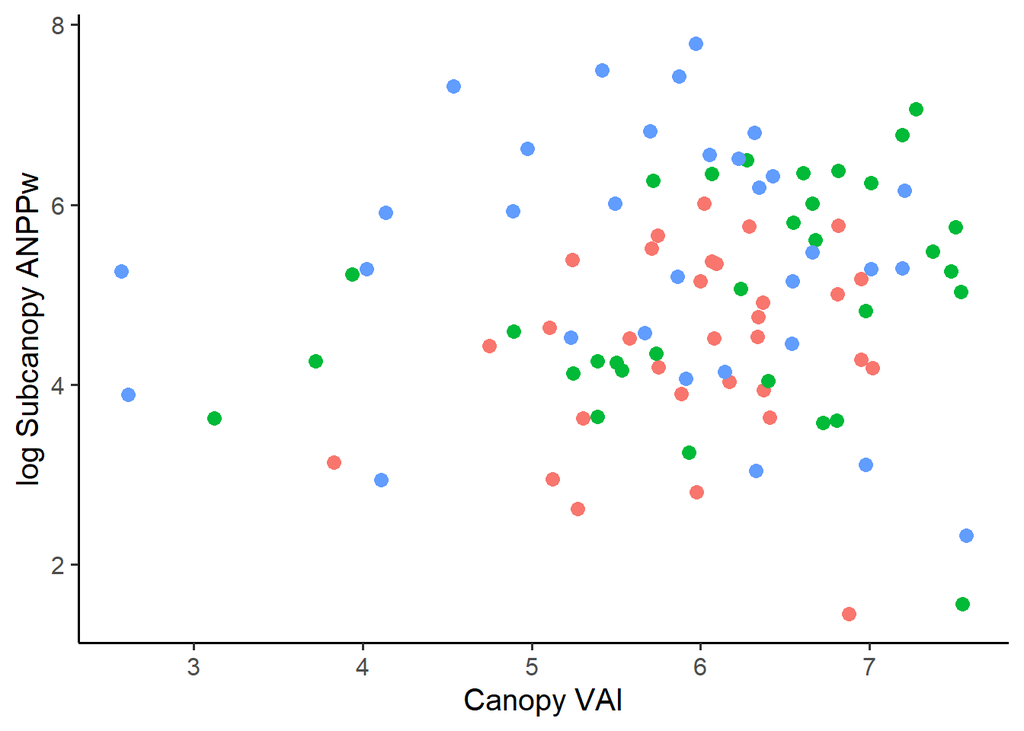

```
## Linear mixed model fit by REML. t-tests use Satterthwaite's method [
## lmerModLmerTest]
## Formula: Subcanopy_NPP ~ mean_vai * Year + (1 | Replicate)
##    Data: npp_vai
##
## REML criterion at convergence: 1323.9
##
## Scaled residuals:
##     Min      1Q  Median      3Q     Max
## -1.6450 -0.5270 -0.1109  0.3075  4.8129
##
## Random effects:
##  Groups    Name        Variance Std.Dev.
##  Replicate (Intercept)  50362   224.4
##  Residual              124640   353.0
## Number of obs: 95, groups:  Replicate, 4
##
## Fixed effects:
##                   Estimate Std. Error       df t value Pr(>|t|)
## (Intercept)        648.181    596.175   85.674   1.087    0.280
## mean_vai           -88.581     97.582   88.950  -0.908    0.366
## Year2020          -204.832    646.231   85.946  -0.317    0.752
## Year2021           381.033    626.779   86.566   0.608    0.545
## mean_vai:Year2020   60.374    106.154   85.993   0.569    0.571
## mean_vai:Year2021   -4.679    104.906   86.513  -0.045    0.965
##
## Correlation of Fixed Effects:
##             (Intr) mean_v Yr2020 Yr2021 m_:Y2020
## mean_vai    -0.976
## Year2020    -0.771  0.778
## Year2021    -0.835  0.843  0.726
## mn_v:Yr2020  0.781 -0.799 -0.990 -0.731
## mn_v:Yr2021  0.822 -0.841 -0.715 -0.990  0.731
```

|  | Subcanopy_NPP |  |  |
| --- | --- | --- | --- |
| Predictors | Estimates | CI | p |
| (Intercept) | 648.18 | -536.78 – 1833.14 | 0.280 |
| mean vai | -88.58 | -282.54 – 105.37 | 0.367 |
| Year [2020] | -204.83 | -1489.29 – 1079.62 | 0.752 |
| Year [2021] | 381.03 | -864.76 – 1626.82 | 0.545 |
| mean vai * Year [2020] | 60.37 | -150.62 – 271.37 | 0.571 |
| mean vai * Year [2021] | -4.68 | -213.19 – 203.83 | 0.965 |
| Random Effects |  |  |  |
| σ<sup>2</sup> | 124639.61 |  |  |
| τ<sub>00</sub> <sub>Replicate</sub> | 50362.01 |  |  |
| ICC | 0.29 |  |  |
| N <sub>Replicate</sub> | 4 |  |  |
| Observations | 95 |  |  |
| Marginal R<sup>2</sup> / Conditional R<sup>2</sup> | 0.148 / 0.393 |  |  |

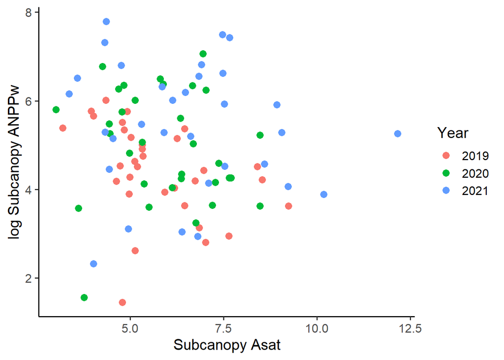

```
##
## Call:
## lm(formula = log_NPP ~ Subplot_mean_Asat, data = traits_npp)
##
## Residuals:
##     Min      1Q  Median      3Q     Max
## -3.5976 -0.7264  0.0725  0.9462  2.7076
##
## Coefficients:
##                   Estimate Std. Error t value Pr(>|t|)
## (Intercept)        5.44314    0.50581  10.761   <2e-16 ***
## Subplot_mean_Asat -0.08252    0.08053  -1.025    0.308
## ---
## Signif. codes:  0 '***' 0.001 '**' 0.01 '*' 0.05 '.' 0.1 ' ' 1
##
## Residual standard error: 1.307 on 94 degrees of freedom
## Multiple R-squared:  0.01105,    Adjusted R-squared:  0.0005266
## F-statistic:  1.05 on 1 and 94 DF,  p-value: 0.3081
```

|  | log_NPP |  |  |
| --- | --- | --- | --- |
| Predictors | Estimates | CI | p |
| (Intercept) | 5.44 | 4.44 – 6.45 | **<0.001** |
| Subplot mean Asat | -0.08 | -0.24 – 0.08 | 0.308 |
| Observations | 96 |  |  |
| R<sup>2</sup> / R<sup>2</sup> adjusted | 0.011 / 0.001 |  |  |

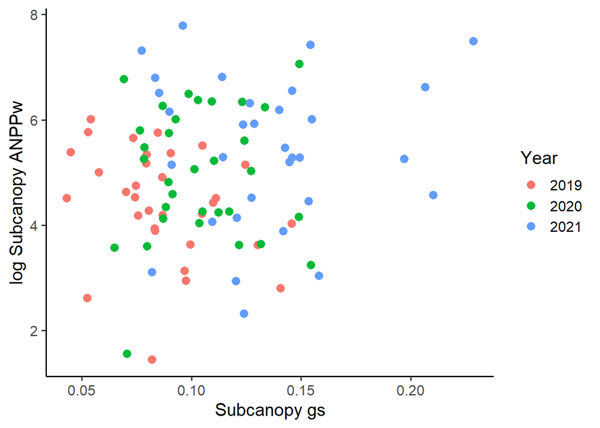

```
##
## Call:
## lm(formula = log_NPP ~ Subplot_mean_Cond, data = traits_npp)
##
## Residuals:
##     Min      1Q  Median      3Q     Max
## -3.3618 -0.8765  0.0721  0.9568  2.9088
##
## Coefficients:
##                   Estimate Std. Error t value Pr(>|t|)
## (Intercept)         4.3971     0.4266  10.307   <2e-16 ***
## Subplot_mean_Cond   5.0518     3.7503   1.347    0.181
## ---
## Signif. codes:  0 '***' 0.001 '**' 0.01 '*' 0.05 '.' 0.1 ' ' 1
##
## Residual standard error: 1.302 on 94 degrees of freedom
## Multiple R-squared:  0.01894,    Adjusted R-squared:  0.008501
## F-statistic: 1.815 on 1 and 94 DF,  p-value: 0.1812
```

|  | log_NPP |  |  |
| --- | --- | --- | --- |
| Predictors | Estimates | CI | p |
| (Intercept) | 4.40 | 3.55 – 5.24 | **<0.001** |
| Subplot mean Cond | 5.05 | -2.39 – 12.50 | 0.181 |
| Observations | 96 |  |  |
| R<sup>2</sup> / R<sup>2</sup> adjusted | 0.019 / 0.009 |  |  |

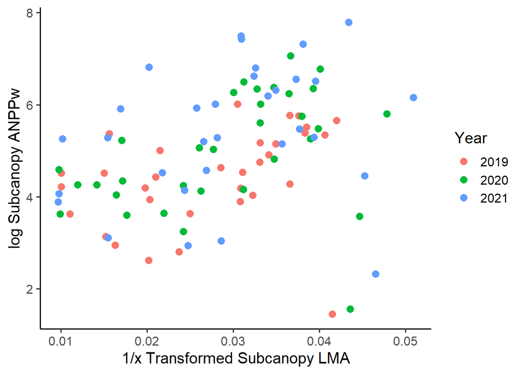

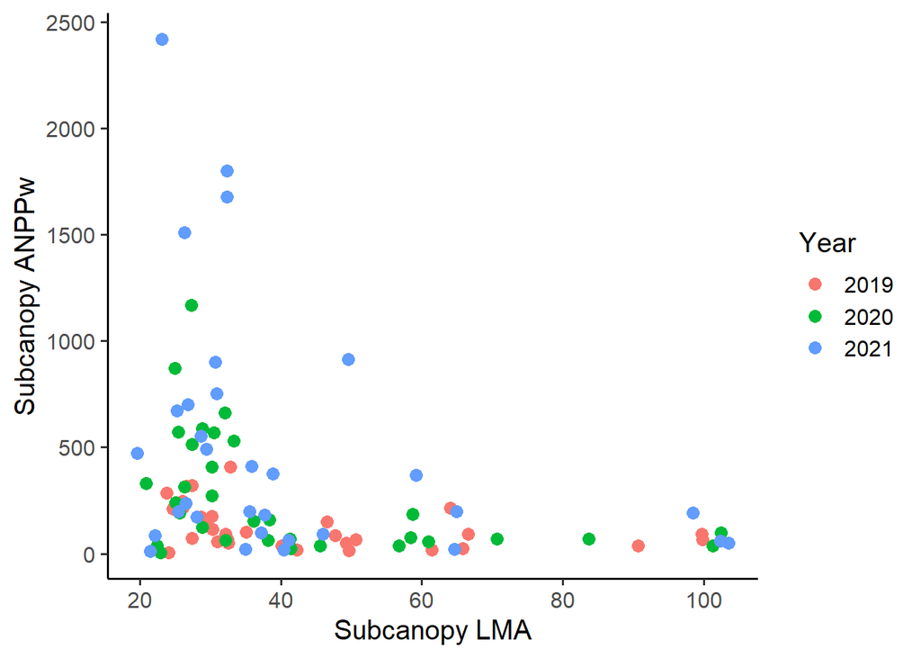

```
##
## Call:
## lm(formula = log_NPP ~ trans_lma, data = traits_npp_lmatrans)
##
## Residuals:
##     Min      1Q  Median      3Q     Max
## -4.0386 -0.5830  0.0355  0.9576  2.4560
##
## Coefficients:
##             Estimate Std. Error t value Pr(>|t|)
## (Intercept)   3.7312     0.3718  10.035  < 2e-16 ***
## trans_lma    42.3635    12.2228   3.466 0.000798 ***
## ---
## Signif. codes:  0 '***' 0.001 '**' 0.01 '*' 0.05 '.' 0.1 ' ' 1
##
## Residual standard error: 1.238 on 94 degrees of freedom
## Multiple R-squared:  0.1133, Adjusted R-squared:  0.1039
## F-statistic: 12.01 on 1 and 94 DF,  p-value: 0.0007982
```

|  | log_NPP |  |  |
| --- | --- | --- | --- |
| Predictors | Estimates | CI | p |
| (Intercept) | 3.73 | 2.99 – 4.47 | **<0.001** |
| trans lma | 42.36 | 18.09 – 66.63 | **0.001** |
| Observations | 96 |  |  |
| R<sup>2</sup> / R<sup>2</sup> adjusted | 0.113 / 0.104 |  |  |

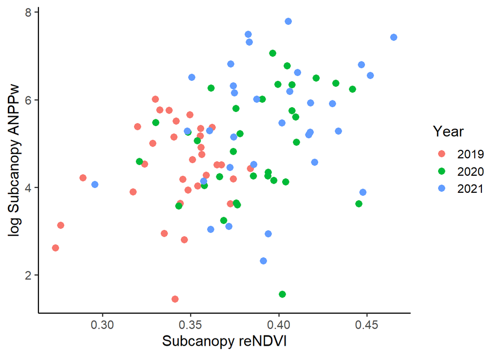

```
##
## Call:
## lm(formula = log_NPP ~ mean_rendvi, data = traits_npp)
##
## Residuals:
##     Min      1Q  Median      3Q     Max
## -3.7373 -0.7102  0.2024  0.8711  2.4495
##
## Coefficients:
##             Estimate Std. Error t value Pr(>|t|)
## (Intercept)   0.1841     1.2252   0.150 0.880869
## mean_rendvi  12.7199     3.2579   3.904 0.000178 ***
## ---
## Signif. codes:  0 '***' 0.001 '**' 0.01 '*' 0.05 '.' 0.1 ' ' 1
##
## Residual standard error: 1.219 on 94 degrees of freedom
## Multiple R-squared:  0.1395, Adjusted R-squared:  0.1304
## F-statistic: 15.24 on 1 and 94 DF,  p-value: 0.0001777
```

|  | log_NPP |  |  |
| --- | --- | --- | --- |
| Predictors | Estimates | CI | p |
| (Intercept) | 0.18 | -2.25 – 2.62 | 0.881 |
| mean rendvi | 12.72 | 6.25 – 19.19 | **<0.001** |
| Observations | 96 |  |  |
| R<sup>2</sup> / R<sup>2</sup> adjusted | 0.140 / 0.130 |  |  |

```
## Linear mixed model fit by REML. t-tests use Satterthwaite's method [
## lmerModLmerTest]
## Formula: Subcanopy_NPP ~ Subplot_mean_Asat + Subplot_mean_Cond + mean_lma +
##     mean_rendvi + (1 | Replicate)
##    Data: traits_npp
##
## REML criterion at convergence: 1347.9
##
## Scaled residuals:
##     Min      1Q  Median      3Q     Max
## -1.6328 -0.4931 -0.1906  0.2084  5.0488
##
## Random effects:
##  Groups    Name        Variance Std.Dev.
##  Replicate (Intercept)  12442   111.5
##  Residual              130667   361.5
## Number of obs: 96, groups:  Replicate, 4
##
## Fixed effects:
##                   Estimate Std. Error       df t value Pr(>|t|)
## (Intercept)       -914.641    394.972   85.637  -2.316   0.0230 *
## Subplot_mean_Asat  -25.900     55.795   88.187  -0.464   0.6436
## Subplot_mean_Cond 1545.669   1826.466   90.870   0.846   0.3996
## mean_lma            -2.076      3.356   80.847  -0.619   0.5379
## mean_rendvi       3445.660   1124.514   87.649   3.064   0.0029 **
## ---
## Signif. codes:  0 '***' 0.001 '**' 0.01 '*' 0.05 '.' 0.1 ' ' 1
##
## Correlation of Fixed Effects:
##             (Intr) Sbp__A Sbp__C men_lm
## Sbplt_mn_As -0.012
## Sbplt_mn_Cn  0.136 -0.757
## mean_lma    -0.215 -0.722  0.510
## mean_rendvi -0.893 -0.194 -0.159  0.207
```

```
## [1] 1363.153
```

```
## [1] 1370.895
```

```
## [1] 1365.433
```

```
## [1] 1378.358
```

```
## Linear mixed model fit by REML. t-tests use Satterthwaite's method [
## lmerModLmerTest]
## Formula: Subcanopy_NPP ~ mean_rendvi + (1 | Replicate)
##    Data: traits_npp
##
## REML criterion at convergence: 1379.1
##
## Scaled residuals:
##     Min      1Q  Median      3Q     Max
## -1.6782 -0.4756 -0.2152  0.1650  5.0772
##
## Random effects:
##  Groups    Name        Variance Std.Dev.
##  Replicate (Intercept)  27697   166.4
##  Residual              126365   355.5
## Number of obs: 96, groups:  Replicate, 4
##
## Fixed effects:
##             Estimate Std. Error       df t value Pr(>|t|)
## (Intercept) -1128.49     367.11    91.42  -3.074 0.002784 **
## mean_rendvi  3810.74     950.72    91.06   4.008 0.000125 ***
## ---
## Signif. codes:  0 '***' 0.001 '**' 0.01 '*' 0.05 '.' 0.1 ' ' 1
##
## Correlation of Fixed Effects:
##             (Intr)
## mean_rendvi -0.969
```

```
## [1] 1387.511
```

```
## Determining predictor order
```

```
## Fitting via lm: Subcanopy_NPP ~ 1
```

```
## Currently evaluating LRT for: mean_lma, mean_rendvi, Subplot_mean_Asat,
##     Subplot_mean_Cond
```

```
## Fitting via lm: Subcanopy_NPP ~ 1 + mean_lma
```

```
## Fitting via lm: Subcanopy_NPP ~ 1 + mean_rendvi
```

```
## Fitting via lm: Subcanopy_NPP ~ 1 + Subplot_mean_Asat
```

```
## Fitting via lm: Subcanopy_NPP ~ 1 + Subplot_mean_Cond
```

```
## Updating formula: Subcanopy_NPP ~ 1 + mean_rendvi
```

```
## Currently evaluating LRT for: mean_lma, Subplot_mean_Asat,
##     Subplot_mean_Cond
```

```
## Fitting via lm: Subcanopy_NPP ~ 1 + mean_rendvi + mean_lma
```

```
## Fitting via lm: Subcanopy_NPP ~ 1 + mean_rendvi + Subplot_mean_Asat
```

```
## Fitting via lm: Subcanopy_NPP ~ 1 + mean_rendvi + Subplot_mean_Cond
```

```
## Updating formula: Subcanopy_NPP ~ 1 + mean_rendvi + mean_lma
```

```
## Currently evaluating LRT for: Subplot_mean_Asat, Subplot_mean_Cond
```

```
## Fitting via lm: Subcanopy_NPP ~ 1 + mean_rendvi + mean_lma +
##     Subplot_mean_Asat
```

```
## Fitting via lm: Subcanopy_NPP ~ 1 + mean_rendvi + mean_lma +
##     Subplot_mean_Cond
```

```
## Updating formula: Subcanopy_NPP ~ 1 + mean_rendvi + mean_lma +
##     Subplot_mean_Cond
```

```
## Currently evaluating LRT for: Subplot_mean_Asat
```

```
## Fitting via lm: Subcanopy_NPP ~ 1 + mean_rendvi + mean_lma +
##     Subplot_mean_Cond + Subplot_mean_Asat
```

```
## Updating formula: Subcanopy_NPP ~ 1 + mean_rendvi + mean_lma +
##     Subplot_mean_Cond + Subplot_mean_Asat
```

```
## Fitting via gam, with REML: Subcanopy_NPP ~ 1 + mean_rendvi + mean_lma
##     + Subplot_mean_Cond + Subplot_mean_Asat
```

```
## Currently evaluating LRT for: 1 | Replicate
```

```
## Fitting via lme, with REML: Subcanopy_NPP ~ 1 + mean_rendvi + mean_lma
##     + Subplot_mean_Cond + Subplot_mean_Asat, random=~1 | Replicate
```

```
## Updating formula: Subcanopy_NPP ~ 1 + mean_rendvi + mean_lma +
##     Subplot_mean_Cond + Subplot_mean_Asat + (1 | Replicate)
```

```
## Fitting ML and REML reference models
```

```
## Fitting via lme, with REML: Subcanopy_NPP ~ 1 + mean_rendvi + mean_lma
##     + Subplot_mean_Cond + Subplot_mean_Asat, random=~1 | Replicate
```

```
## Fitting via lme, with ML: Subcanopy_NPP ~ 1 + mean_rendvi + mean_lma +
##     Subplot_mean_Cond + Subplot_mean_Asat, random=~1 | Replicate
```

```
## Testing terms
```

```
## Fitting via lme, with ML: Subcanopy_NPP ~ 1 + mean_lma +
##     Subplot_mean_Cond + Subplot_mean_Asat, random=~1 | Replicate
```

```
## Fitting via lme, with ML: Subcanopy_NPP ~ 1 + mean_rendvi +
##     Subplot_mean_Cond + Subplot_mean_Asat, random=~1 | Replicate
```

```
## Fitting via lme, with ML: Subcanopy_NPP ~ 1 + mean_rendvi + mean_lma +
##     Subplot_mean_Asat, random=~1 | Replicate
```

```
## Fitting via lme, with ML: Subcanopy_NPP ~ 1 + mean_rendvi + mean_lma +
##     Subplot_mean_Cond, random=~1 | Replicate
```

```
## Fitting via gam, with REML: Subcanopy_NPP ~ 1 + mean_rendvi + mean_lma
##     + Subplot_mean_Cond + Subplot_mean_Asat
```

```
##     grouping              term                   block       score Iteration
## 1       <NA>                 1                 NA NA 1          NA         1
## 2       <NA>       mean_rendvi       NA NA mean_rendvi  -8.5385989         1
## 3       <NA>          mean_lma          NA NA mean_lma  -6.0131803         1
## 21      <NA> Subplot_mean_Cond NA NA Subplot_mean_Cond  -0.6999975         1
## 11      <NA> Subplot_mean_Asat NA NA Subplot_mean_Asat  -1.0229535         1
## 12 Replicate                 1          NA Replicate 1 -27.3213123         1
##             LRT
## 1            NA
## 2  1.963638e-03
## 3  4.018541e-01
## 21 3.036284e-01
## 11 4.671582e-01
## 12 1.363028e-12
```

```
## Updating formula: Subcanopy_NPP ~ 1 + mean_rendvi + mean_lma +
##     Subplot_mean_Cond + (1 | Replicate)
```

```
## Fitting ML and REML reference models
```

```
## Fitting via lme, with REML: Subcanopy_NPP ~ 1 + mean_rendvi + mean_lma
##     + Subplot_mean_Cond, random=~1 | Replicate
```

```
## Fitting via lme, with ML: Subcanopy_NPP ~ 1 + mean_rendvi + mean_lma +
##     Subplot_mean_Cond, random=~1 | Replicate
```

```
## Testing terms
```

```
## Fitting via lme, with ML: Subcanopy_NPP ~ 1 + mean_lma +
##     Subplot_mean_Cond, random=~1 | Replicate
```

```
## Fitting via lme, with ML: Subcanopy_NPP ~ 1 + mean_rendvi +
##     Subplot_mean_Cond, random=~1 | Replicate
```

```
## Fitting via lme, with ML: Subcanopy_NPP ~ 1 + mean_rendvi + mean_lma,
##     random=~1 | Replicate
```

```
## Fitting via gam, with REML: Subcanopy_NPP ~ 1 + mean_rendvi + mean_lma
##     + Subplot_mean_Cond
```

```
##     grouping              term                   block       score Iteration
## 1       <NA>                 1                 NA NA 1          NA         2
## 2       <NA>       mean_rendvi       NA NA mean_rendvi  -8.5385989         2
## 3       <NA>          mean_lma          NA NA mean_lma  -6.0131803         2
## 21      <NA> Subplot_mean_Cond NA NA Subplot_mean_Cond  -0.6999975         2
## 12 Replicate                 1          NA Replicate 1 -27.3213123         2
##             LRT
## 1            NA
## 2  2.600931e-03
## 3  1.702452e-01
## 21 4.626435e-01
## 12 1.377532e-10
```

```
## Updating formula: Subcanopy_NPP ~ 1 + mean_rendvi + mean_lma + (1 |
##     Replicate)
```

```
## Fitting ML and REML reference models
```

```
## Fitting via lme, with REML: Subcanopy_NPP ~ 1 + mean_rendvi + mean_lma,
##     random=~1 | Replicate
```

```
## Fitting via lme, with ML: Subcanopy_NPP ~ 1 + mean_rendvi + mean_lma,
##     random=~1 | Replicate
```

```
## Testing terms
```

```
## Fitting via lme, with ML: Subcanopy_NPP ~ 1 + mean_lma, random=~1 |
##     Replicate
```

```
## Fitting via lme, with ML: Subcanopy_NPP ~ 1 + mean_rendvi, random=~1 |
##     Replicate
```

```
## Fitting via gam, with REML: Subcanopy_NPP ~ 1 + mean_rendvi + mean_lma
```

```
##     grouping        term             block      score Iteration          LRT
## 1       <NA>           1           NA NA 1         NA         3           NA
## 2       <NA> mean_rendvi NA NA mean_rendvi  -8.538599         3 1.820605e-04
## 3       <NA>    mean_lma    NA NA mean_lma  -6.013180         3 1.725254e-01
## 12 Replicate           1    NA Replicate 1 -27.321312         3 4.364079e-07
```

```
## Updating formula: Subcanopy_NPP ~ 1 + mean_rendvi + (1 | Replicate)
```

```
## Fitting ML and REML reference models
```

```
## Fitting via lme, with REML: Subcanopy_NPP ~ 1 + mean_rendvi, random=~1
##     | Replicate
```

```
## Fitting via lme, with ML: Subcanopy_NPP ~ 1 + mean_rendvi, random=~1 |
##     Replicate
```

```
## Testing terms
```

```
## Fitting via lme, with ML: Subcanopy_NPP ~ 1, random=~1 | Replicate
```

```
## Fitting via gam, with REML: Subcanopy_NPP ~ 1 + mean_rendvi
```

```
##     grouping        term             block      score Iteration          LRT
## 1       <NA>           1           NA NA 1         NA         4           NA
## 2       <NA> mean_rendvi NA NA mean_rendvi  -8.538599         4 1.053022e-04
## 12 Replicate           1    NA Replicate 1 -27.321312         4 4.279912e-08
```

```
## All terms are significant
```

```
## Linear mixed-effects model fit by REML
##  Data: traits_npp
##        AIC      BIC    logLik
##   1387.071 1397.244 -689.5356
##
## Random effects:
##  Formula: ~1 | Replicate
##         (Intercept) Residual
## StdDev:    166.4229  355.478
##
## Fixed effects: Subcanopy_NPP ~ 1 + mean_rendvi
##                 Value Std.Error DF   t-value p-value
## (Intercept) -1128.486  367.1056 91 -3.074010  0.0028
## mean_rendvi  3810.737  950.7165 91  4.008279  0.0001
##  Correlation:
##             (Intr)
## mean_rendvi -0.969
##
## Standardized Within-Group Residuals:
##        Min         Q1        Med         Q3        Max
## -1.6782356 -0.4756467 -0.2151706  0.1649989  5.0772242
##
## Number of Observations: 96
## Number of Groups: 4
```

```
## [1] 1387.511
```

```
##
## Call:
## lm(formula = log_NPP ~ Subplot_mean_Asat + Subplot_mean_Cond +
##     mean_rendvi + trans_lma + Replicate, data = traits_npp_lmatrans)
##
## Residuals:
##     Min      1Q  Median      3Q     Max
## -4.1158 -0.7169  0.1768  0.6788  2.0673
##
## Coefficients:
##                   Estimate Std. Error t value Pr(>|t|)
## (Intercept)        0.55759    1.82005   0.306  0.76005
## Subplot_mean_Asat  0.14328    0.19793   0.724  0.47107
## Subplot_mean_Cond -2.95473    5.94088  -0.497  0.62018
## mean_rendvi       11.59065    3.62176   3.200  0.00191 **
## trans_lma          2.90853   33.67950   0.086  0.93138
## ReplicateB        -0.03784    0.36445  -0.104  0.91754
## ReplicateC        -0.78643    0.51918  -1.515  0.13342
## ReplicateD        -1.50730    0.70671  -2.133  0.03572 *
## ---
## Signif. codes:  0 '***' 0.001 '**' 0.01 '*' 0.05 '.' 0.1 ' ' 1
##
## Residual standard error: 1.143 on 88 degrees of freedom
## Multiple R-squared:  0.2919, Adjusted R-squared:  0.2355
## F-statistic: 5.182 on 7 and 88 DF,  p-value: 5.704e-05
```

```
## [1] 307.7601
```

```
## [1] 309.8531
```

```
## Start:  AIC=33.32
## log_NPP ~ Subplot_mean_Asat + Subplot_mean_Cond + mean_rendvi +
##     trans_lma + Replicate
##
##                     Df Sum of Sq    RSS    AIC
## - trans_lma          1    0.0097 115.00 31.332
## - Subplot_mean_Cond  1    0.3232 115.31 31.593
## - Subplot_mean_Asat  1    0.6847 115.67 31.894
## <none>                           114.98 33.324
## - Replicate          3    8.3146 123.30 34.026
## - mean_rendvi        1   13.3825 128.37 41.893
##
## Step:  AIC=31.33
## log_NPP ~ Subplot_mean_Asat + Subplot_mean_Cond + mean_rendvi +
##     Replicate
##
##                     Df Sum of Sq    RSS    AIC
## - Subplot_mean_Cond  1    0.3383 115.33 29.614
## - Subplot_mean_Asat  1    0.9901 115.98 30.155
## <none>                           115.00 31.332
## + trans_lma          1    0.0097 114.98 33.324
## - Replicate          3   14.3344 129.33 36.610
## - mean_rendvi        1   14.4993 129.49 40.732
##
## Step:  AIC=29.61
## log_NPP ~ Subplot_mean_Asat + mean_rendvi + Replicate
##
##                     Df Sum of Sq    RSS    AIC
## - Subplot_mean_Asat  1    0.6848 116.02 28.182
## <none>                           115.33 29.614
## + Subplot_mean_Cond  1    0.3383 115.00 31.332
## + trans_lma          1    0.0248 115.31 31.593
## - Replicate          3   16.0572 131.39 36.127
## - mean_rendvi        1   14.2995 129.63 38.834
##
## Step:  AIC=28.18
## log_NPP ~ mean_rendvi + Replicate
##
##                     Df Sum of Sq    RSS    AIC
## <none>                           116.02 28.182
## + Subplot_mean_Asat  1    0.6848 115.33 29.614
## + trans_lma          1    0.3374 115.68 29.903
## + Subplot_mean_Cond  1    0.0330 115.98 30.155
## - Replicate          3   23.7033 139.72 40.029
## - mean_rendvi        1   21.1304 137.15 42.245
```

```
##
## Call:
## lm(formula = log_NPP ~ mean_rendvi + Replicate, data = traits_npp_lmatrans)
##
## Coefficients:
## (Intercept)  mean_rendvi   ReplicateB   ReplicateC   ReplicateD
##    0.802097    12.295984     0.003099    -0.656847    -1.183795
```

```
##
## Call:
## lm(formula = log_NPP ~ mean_rendvi * disturbance_severity * Year +
##     Replicate, data = traits_npp)
##
## Residuals:
##     Min      1Q  Median      3Q     Max
## -2.8318 -0.4834 -0.0487  0.5565  2.1033
##
## Coefficients:
##                                             Estimate Std. Error t value
## (Intercept)                                 -11.7174    10.6609  -1.099
## mean_rendvi                                  46.8947    30.3371   1.546
## disturbance_severity45                        9.2085    11.2586   0.818
## disturbance_severity65                       16.5485    11.6264   1.423
## disturbance_severity85                       18.1489    11.6712   1.555
## Year2020                                     33.0758    11.7455   2.816
## Year2021                                     27.4638    11.7435   2.339
## ReplicateB                                   -0.2057     0.2815  -0.731
## ReplicateC                                   -0.6868     0.2813  -2.442
## ReplicateD                                   -1.5467     0.3007  -5.143
## mean_rendvi:disturbance_severity45          -24.1565    32.1022  -0.752
## mean_rendvi:disturbance_severity65          -46.1320    33.2524  -1.387
## mean_rendvi:disturbance_severity85          -51.1444    33.4304  -1.530
## mean_rendvi:Year2020                        -94.1690    33.3145  -2.827
## mean_rendvi:Year2021                        -77.7048    33.2875  -2.334
## disturbance_severity45:Year2020             -30.5647    13.9876  -2.185
## disturbance_severity65:Year2020             -27.2731    13.9773  -1.951
## disturbance_severity85:Year2020             -35.2280    14.2255  -2.476
## disturbance_severity45:Year2021             -15.9036    13.6612  -1.164
## disturbance_severity65:Year2021             -22.8529    14.0036  -1.632
## disturbance_severity85:Year2021             -29.7543    14.0570  -2.117
## mean_rendvi:disturbance_severity45:Year2020  86.4927    38.9383   2.221
## mean_rendvi:disturbance_severity65:Year2020  81.0251    39.1030   2.072
## mean_rendvi:disturbance_severity85:Year2020 103.3210    39.3475   2.626
## mean_rendvi:disturbance_severity45:Year2021  47.1248    38.0753   1.238
## mean_rendvi:disturbance_severity65:Year2021  69.3645    39.1241   1.773
## mean_rendvi:disturbance_severity85:Year2021  88.6979    38.9151   2.279
##                                             Pr(>|t|)
## (Intercept)                                  0.27555
```

[output cut: 17 more lines]

```
## disturbance_severity45:Year2021              0.24837
## disturbance_severity65:Year2021              0.10725
## disturbance_severity85:Year2021              0.03789 *
## mean_rendvi:disturbance_severity45:Year2020  0.02962 *
## mean_rendvi:disturbance_severity65:Year2020  0.04200 *
## mean_rendvi:disturbance_severity85:Year2020  0.01064 *
## mean_rendvi:disturbance_severity45:Year2021  0.22003
## mean_rendvi:disturbance_severity65:Year2021  0.08065 .
## mean_rendvi:disturbance_severity85:Year2021  0.02575 *
## ---
## Signif. codes:  0 '***' 0.001 '**' 0.01 '*' 0.05 '.' 0.1 ' ' 1
##
## Residual standard error: 0.938 on 69 degrees of freedom
## Multiple R-squared:  0.6261, Adjusted R-squared:  0.4852
## F-statistic: 4.444 on 26 and 69 DF,  p-value: 3.709e-07
```

```
## [1] 308.6895
```

```
## Start:  AIC=10.01
## log_NPP ~ mean_rendvi * disturbance_severity * Year + Replicate
##
##                                         Df Sum of Sq    RSS    AIC
## - mean_rendvi:disturbance_severity:Year  6     7.864 68.577  9.707
## <none>                                               60.713 10.014
## - Replicate                              3    26.899 87.613 39.224
##
## Step:  AIC=9.71
## log_NPP ~ mean_rendvi + disturbance_severity + Year + Replicate +
##     mean_rendvi:disturbance_severity + mean_rendvi:Year + disturbance_severity:Year
##
##                                         Df Sum of Sq    RSS    AIC
## - disturbance_severity:Year              6    5.8852 74.463  5.611
## - mean_rendvi:Year                       2    2.1539 70.731  8.676
## <none>                                               68.577  9.707
## + mean_rendvi:disturbance_severity:Year  6    7.8640 60.713 10.014
## - mean_rendvi:disturbance_severity       3    7.2356 75.813 13.337
## - Replicate                              3   25.5683 94.146 34.128
##
## Step:  AIC=5.61
## log_NPP ~ mean_rendvi + disturbance_severity + Year + Replicate +
##     mean_rendvi:disturbance_severity + mean_rendvi:Year
##
##                                    Df Sum of Sq     RSS     AIC
## - mean_rendvi:Year                  2    1.8640  76.327  3.9847
## <none>                                           74.463  5.6112
## + disturbance_severity:Year         6    5.8852  68.577  9.7071
## - mean_rendvi:disturbance_severity  3   13.4339  87.897 15.5341
## - Replicate                         3   27.0433 101.506 29.3539
##
## Step:  AIC=3.98
## log_NPP ~ mean_rendvi + disturbance_severity + Year + Replicate +
##     mean_rendvi:disturbance_severity
##
##                                    Df Sum of Sq     RSS     AIC
## <none>                                           76.327  3.9847
## - Year                              2    4.5963  80.923  5.5984
## + mean_rendvi:Year                  2    1.8640  74.463  5.6112
## + disturbance_severity:Year         6    5.5953  70.731  8.6759
## - mean_rendvi:disturbance_severity  3   16.4633  92.790 16.7350
## - Replicate                         3   26.9255 103.252 26.9913
```

```
##
## Call:
## lm(formula = log_NPP ~ mean_rendvi + disturbance_severity + Year +
##     Replicate + mean_rendvi:disturbance_severity, data = traits_npp)
##
## Coefficients:
##                        (Intercept)                         mean_rendvi
##                            15.4869                            -31.3559
##             disturbance_severity45              disturbance_severity65
##                           -13.5089                            -10.8423
##             disturbance_severity85                            Year2020
##                           -14.2208                              0.2485
##                           Year2021                          ReplicateB
##                             0.6485                             -0.2342
##                         ReplicateC                          ReplicateD
##                            -0.7016                             -1.4179
## mean_rendvi:disturbance_severity45  mean_rendvi:disturbance_severity65
##                            40.4520                             33.4171
## mean_rendvi:disturbance_severity85
##                            42.9139
```

```
##
## Call:
## lm(formula = log_NPP ~ mean_rendvi + disturbance_severity + Year +
##     Replicate + mean_rendvi:disturbance_severity, data = traits_npp)
##
## Residuals:
##     Min      1Q  Median      3Q     Max
## -3.3395 -0.5930  0.0952  0.5528  1.9704
##
## Coefficients:
##                                    Estimate Std. Error t value Pr(>|t|)
## (Intercept)                         15.4869     3.3439   4.631 1.33e-05 ***
## mean_rendvi                        -31.3559     9.3237  -3.363 0.001168 **
## disturbance_severity45             -13.5089     4.1928  -3.222 0.001820 **
## disturbance_severity65             -10.8423     3.9843  -2.721 0.007922 **
## disturbance_severity85             -14.2208     3.7498  -3.792 0.000282 ***
## Year2020                             0.2485     0.2942   0.845 0.400661
## Year2021                             0.6485     0.3103   2.090 0.039691 *
## ReplicateB                          -0.2342     0.2826  -0.829 0.409652
## ReplicateC                          -0.7016     0.2792  -2.513 0.013889 *
## ReplicateD                          -1.4179     0.2864  -4.950 3.84e-06 ***
## mean_rendvi:disturbance_severity45  40.4520    11.5909   3.490 0.000776 ***
## mean_rendvi:disturbance_severity65  33.4171    10.9861   3.042 0.003148 **
## mean_rendvi:disturbance_severity85  42.9139    10.3109   4.162 7.66e-05 ***
## ---
## Signif. codes:  0 '***' 0.001 '**' 0.01 '*' 0.05 '.' 0.1 ' ' 1
##
## Residual standard error: 0.959 on 83 degrees of freedom
## Multiple R-squared:   0.53,  Adjusted R-squared:  0.462
## F-statistic: 7.798 on 12 and 83 DF,  p-value: 1.672e-09
```

```
## [1] 283.6061
```

```
## $emmeans
##  mean_rendvi disturbance_severity emmean    SE df lower.CL upper.CL
##        0.374 0                      3.47 0.265 83     2.94     3.99
##        0.374 45                     5.09 0.196 83     4.70     5.48
##        0.374 65                     5.13 0.197 83     4.73     5.52
##        0.374 85                     5.30 0.213 83     4.88     5.72
##
## Results are averaged over the levels of: Year, Replicate
## Confidence level used: 0.95
##
## $contrasts
##  contrast                                    estimate    SE df t.ratio p.value
##  0.374144198913763 0 - 0.374144198913763 45   -1.6260 0.330 83 -4.932  <.0001
##  0.374144198913763 0 - 0.374144198913763 65   -1.6605 0.330 83 -5.029  <.0001
##  0.374144198913763 0 - 0.374144198913763 85   -1.8352 0.342 83 -5.373  <.0001
##  0.374144198913763 45 - 0.374144198913763 65  -0.0346 0.278 83 -0.124  0.9993
##  0.374144198913763 45 - 0.374144198913763 85  -0.2093 0.290 83 -0.721  0.8885
##  0.374144198913763 65 - 0.374144198913763 85  -0.1747 0.289 83 -0.605  0.9302
##
## Results are averaged over the levels of: Year, Replicate
## P value adjustment: tukey method for comparing a family of 4 estimates
```

|  | log_NPP |  |  |
| --- | --- | --- | --- |
| Predictors | Estimates | CI | p |
| (Intercept) | 15.49 | 8.84 – 22.14 | **<0.001** |
| mean rendvi | -31.36 | -49.90 – -12.81 | **0.001** |
| disturbance severity [45] | -13.51 | -21.85 – -5.17 | **0.002** |
| disturbance severity [65] | -10.84 | -18.77 – -2.92 | **0.008** |
| disturbance severity [85] | -14.22 | -21.68 – -6.76 | **<0.001** |
| Year [2020] | 0.25 | -0.34 – 0.83 | 0.401 |
| Year [2021] | 0.65 | 0.03 – 1.27 | **0.040** |
| Replicate [B] | -0.23 | -0.80 – 0.33 | 0.410 |
| Replicate [C] | -0.70 | -1.26 – -0.15 | **0.014** |
| Replicate [D] | -1.42 | -1.99 – -0.85 | **<0.001** |
| mean rendvi * disturbance severity [45] | 40.45 | 17.40 – 63.51 | **0.001** |
| mean rendvi * disturbance severity [65] | 33.42 | 11.57 – 55.27 | **0.003** |
| mean rendvi * disturbance severity [85] | 42.91 | 22.41 – 63.42 | **<0.001** |
| Observations | 96 |  |  |
| R<sup>2</sup> / R<sup>2</sup> adjusted | 0.530 / 0.462 |  |  |

```
## [1] -5.283792e-18
```

```
##
## Call:
## lm(formula = Subcanopy_NPP ~ Subplot_mean_Asat + Subplot_mean_Cond +
##     mean_rendvi + trans_lma + Replicate, data = traits_npp_lmatrans)
##
## Residuals:
##     Min      1Q  Median      3Q     Max
## -596.11 -180.04  -64.92   87.99 1792.14
##
## Coefficients:
##                   Estimate Std. Error t value Pr(>|t|)
## (Intercept)        -667.21     572.92  -1.165  0.24734
## Subplot_mean_Asat   -14.90      62.31  -0.239  0.81156
## Subplot_mean_Cond  1277.21    1870.09   0.683  0.49642
## mean_rendvi        3465.57    1140.07   3.040  0.00312 **
## trans_lma         -3890.98   10601.72  -0.367  0.71449
## ReplicateB         -249.43     114.72  -2.174  0.03238 *
## ReplicateC         -319.61     163.43  -1.956  0.05368 .
## ReplicateD         -505.36     222.46  -2.272  0.02554 *
## ---
## Signif. codes:  0 '***' 0.001 '**' 0.01 '*' 0.05 '.' 0.1 ' ' 1
##
## Residual standard error: 359.8 on 88 degrees of freedom
## Multiple R-squared:  0.2891, Adjusted R-squared:  0.2325
## F-statistic: 5.112 on 7 and 88 DF,  p-value: 6.636e-05
```

```
## [1] 1414.215
```

```
## Start:  AIC=1137.69
## Subcanopy_NPP ~ Subplot_mean_Asat + Subplot_mean_Cond + mean_rendvi +
##     trans_lma + Replicate
##
##                     Df Sum of Sq      RSS    AIC
## - Subplot_mean_Asat  1      7404 11401095 1135.8
## - trans_lma          1     17440 11411131 1135.8
## - Subplot_mean_Cond  1     60392 11454083 1136.2
## <none>                           11393691 1137.7
## - Replicate          3    820508 12214198 1138.4
## - mean_rendvi        1   1196387 12590077 1145.3
##
## Step:  AIC=1135.75
## Subcanopy_NPP ~ Subplot_mean_Cond + mean_rendvi + trans_lma +
##     Replicate
##
##                     Df Sum of Sq      RSS    AIC
## - trans_lma          1     10040 11411134 1133.8
## - Subplot_mean_Cond  1     78558 11479652 1134.4
## <none>                           11401095 1135.8
## - Replicate          3    816585 12217680 1136.4
## + Subplot_mean_Asat  1      7404 11393691 1137.7
## - mean_rendvi        1   1226771 12627865 1143.6
##
## Step:  AIC=1133.83
## Subcanopy_NPP ~ Subplot_mean_Cond + mean_rendvi + Replicate
##
##                     Df Sum of Sq      RSS    AIC
## - Subplot_mean_Cond  1     88024 11499159 1132.6
## <none>                           11411134 1133.8
## + trans_lma          1     10040 11401095 1135.8
## + Subplot_mean_Asat  1         4 11411131 1135.8
## - mean_rendvi        1   1218237 12629371 1141.6
## - Replicate          3   2450640 13861774 1146.5
##
## Step:  AIC=1132.57
## Subcanopy_NPP ~ mean_rendvi + Replicate
##
##                     Df Sum of Sq      RSS    AIC
## <none>                           11499159 1132.6
## + Subplot_mean_Cond  1     88024 11411134 1133.8
## + Subplot_mean_Asat  1     44135 11455024 1134.2
## + trans_lma          1     19506 11479652 1134.4
## - Replicate          3   2371262 13870421 1144.6
## - mean_rendvi        1   2006666 13505825 1146.0
```

```
##
## Call:
## lm(formula = Subcanopy_NPP ~ mean_rendvi + Replicate, data = traits_npp_lmatrans)
##
## Coefficients:
## (Intercept)  mean_rendvi   ReplicateB   ReplicateC   ReplicateD
##      -885.1       3789.2       -231.5       -268.3       -441.3
```

```
##
## Call:
## lm(formula = log_NPP ~ Subplot_mean_Asat + Subplot_mean_Cond +
##     mean_rendvi + Replicate, data = traits_npp_lmatrans)
##
## Residuals:
##     Min      1Q  Median      3Q     Max
## -4.1123 -0.7179  0.1879  0.6730  2.0708
##
## Coefficients:
##                   Estimate Std. Error t value Pr(>|t|)
## (Intercept)        0.67482    1.20561   0.560  0.57707
## Subplot_mean_Asat  0.13233    0.15117   0.875  0.38373
## Subplot_mean_Cond -2.73702    5.34938  -0.512  0.61016
## mean_rendvi       11.66999    3.48371   3.350  0.00119 **
## ReplicateB        -0.05014    0.33361  -0.150  0.88088
## ReplicateC        -0.81727    0.37474  -2.181  0.03183 *
## ReplicateD        -1.54781    0.52559  -2.945  0.00412 **
## ---
## Signif. codes:  0 '***' 0.001 '**' 0.01 '*' 0.05 '.' 0.1 ' ' 1
##
## Residual standard error: 1.137 on 89 degrees of freedom
## Multiple R-squared:  0.2918, Adjusted R-squared:  0.2441
## F-statistic: 6.112 on 6 and 89 DF,  p-value: 2.15e-05
```

```
## [1] 305.7682
```

```
## [1] 307.4234
```

```
##
## Call:
## lm(formula = log_NPP ~ Subplot_mean_Asat + mean_rendvi + Replicate,
##     data = traits_npp_lmatrans)
##
## Residuals:
##     Min      1Q  Median      3Q     Max
## -4.0720 -0.7099  0.1440  0.6443  2.0748
##
## Coefficients:
##                   Estimate Std. Error t value Pr(>|t|)
## (Intercept)        0.82694    1.16358   0.711  0.47912
## Subplot_mean_Asat  0.07721    0.10562   0.731  0.46666
## mean_rendvi       11.22894    3.36151   3.340  0.00122 **
## ReplicateB        -0.03047    0.33003  -0.092  0.92664
## ReplicateC        -0.76735    0.36032  -2.130  0.03593 *
## ReplicateD        -1.41337    0.45332  -3.118  0.00245 **
## ---
## Signif. codes:  0 '***' 0.001 '**' 0.01 '*' 0.05 '.' 0.1 ' ' 1
##
## Residual standard error: 1.132 on 90 degrees of freedom
## Multiple R-squared:  0.2897, Adjusted R-squared:  0.2503
## F-statistic: 7.343 on 5 and 90 DF,  p-value: 8.226e-06
```

```
## [1] 304.0502
```

```
## [1] 305.3229
```

```
## Levene's Test for Homogeneity of Variance (center = median)
##        Df F value Pr(>F)
## group   3  1.3992 0.2463
##       124
```

```
##
##  Bartlett test of homogeneity of variances
##
## data:  mean_rendvi by Year
## Bartlett's K-squared = 3.4832, df = 3, p-value = 0.3229
```

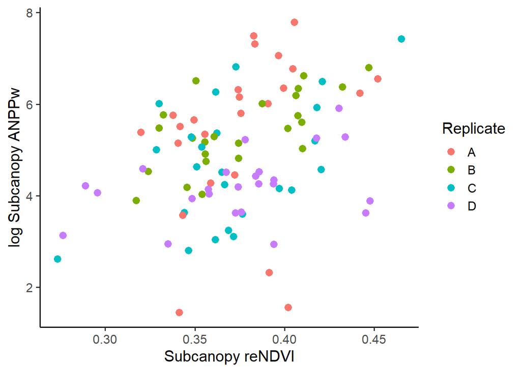

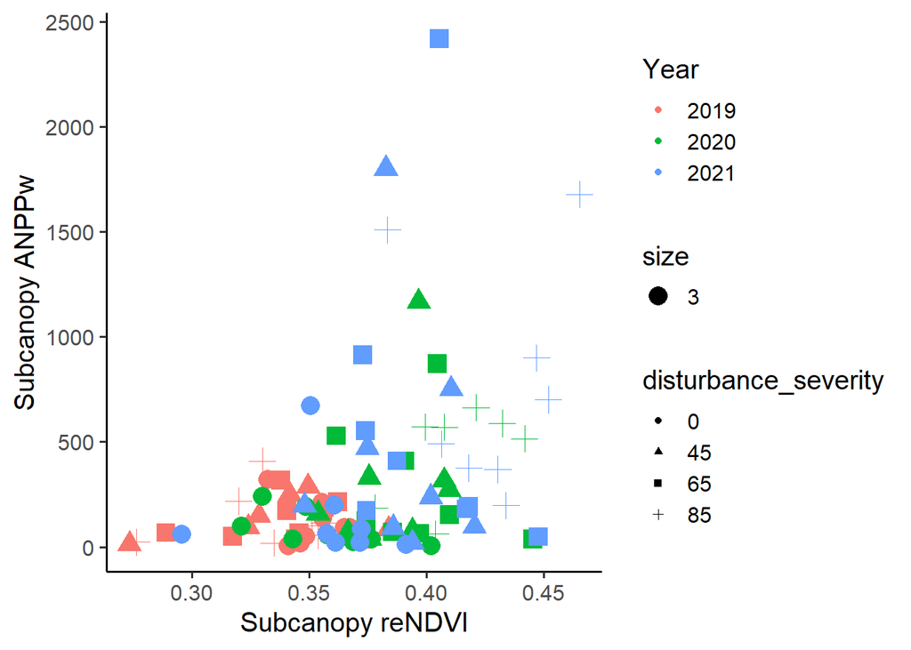

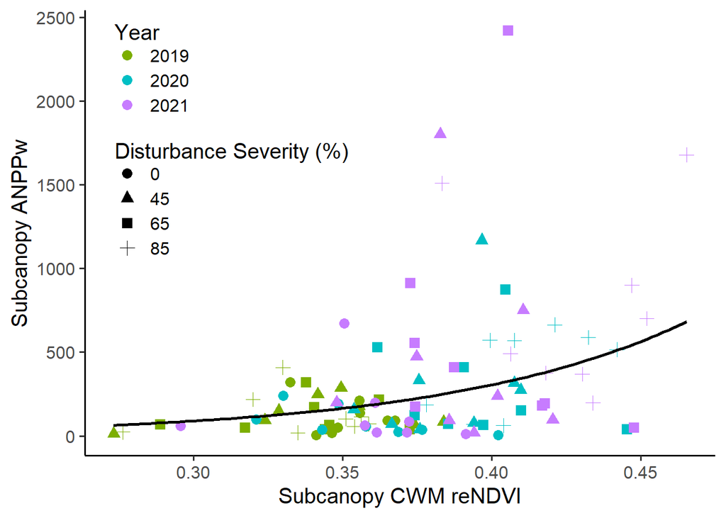

## Conclusions O2.3 (so far…)

Though disturbance was found to influence both canopy VAI and subcanopy ANPPw, VAI was not in turn found to relate to subcanopy ANPPw. This is likely due to the lagged impact of disturbance on VAI, such that it took three years for effects to start manifesting. This also points to the importance of looking for other mechanisms (beyond canopy structure) to explain the more rapid response of subcanopy ANPPw to disturbance (which was already responding significantly in the second year, before VAI). Cue leaf traits!!

I am still working through model selection for this part of the analysis, but have found some interesting results so far. In the model including all leaf functional traits (Asat, gs, LMA, and reNDVI) AND their respective interactions with year, only LMA*Year emerged as significant. However, in a model with all leaf traits but WITHOUT their interactions with Year, reNDVI emerged as significant at alpha=0.1 (p = 0.06) as well as Year (p < 0.5). In subsequent linear mixed effects models removing insignificant leaf functional trait terms of LMA and Asat, reNDVI’s p value dropped to become significant.

# update 8/22/22 (yep, still working on this…)

Leaf traits and NPP continued…

Basically, model ranking gets really hard to follow (at least for me) with the inclusion of fixed and random effects. I was not able to parse the output of mixed effects model ranking in a satisfying way, so I reverted to the use of all fixed effects in linear models (i.e. replicate became a categorical fixed effect for the last part of this analysis).

So…When I ran the stepwise AIC for linear models including log NPP vs. leaf functional traits (including Replicate as a fixed effect covariate), the only predictor that was retained was reNDVI.

```r
## code from Jeff Atkins for making ridge plots of stem diameter by species. To support claims made about size classes of trees targeted in FoRTE for a Supp Doc.
require(fortedata)
require(ggplot2)
require(ggridges)
require(viridis)
# import data
inv <- fd_inventory()
head(inv)
```

```
## # A tibble: 6 x 11
##   subplot_id replicate  plot subplot date         tag species dbh_cm
##   <chr>      <chr>     <int> <chr>   <date>     <int> <chr>    <dbl>
## 1 A01E       A             1 E       2018-07-12  2772 POGR4     36.2
## 2 A01E       A             1 E       2018-07-12  2773 POGR4     41.6
## 3 A01E       A             1 E       2018-07-12  2774 FAGR      10.8
## 4 A01E       A             1 E       2018-07-12  2775 FAGR      26.2
## 5 A01E       A             1 E       2018-07-12  2776 FAGR      19.5
## 6 A01E       A             1 E       2018-07-12  2777 POGR4     26.5
## # ... with 3 more variables: health_status <chr>, canopy_status <chr>,
## #   notes <chr>
```

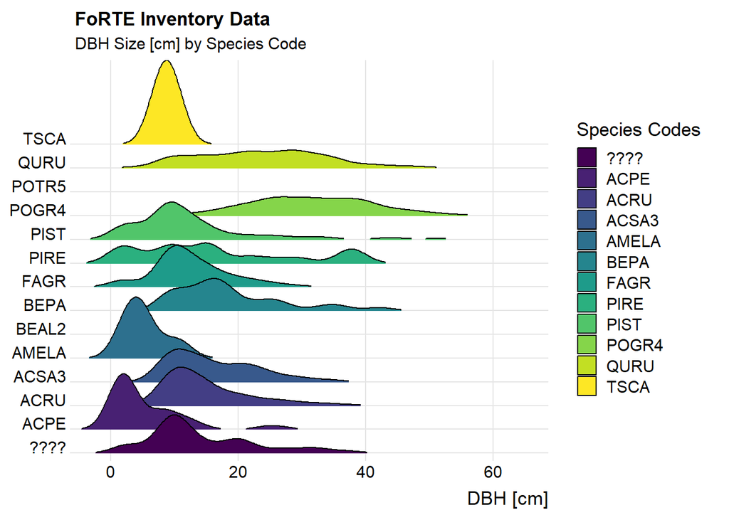

```r
# make ridge plot
x11 <- ggplot(inv, aes(x = dbh_cm, y = species, fill = as.factor(species))) +
    geom_density_ridges_gradient(scale = 3, rel_min_height = 0.01, gradient_lwd = 1.) +
    scale_x_continuous(expand = c(0, 0)) +
    scale_y_discrete(expand = expand_scale(mult = c(0.01, 0.25))) +
    scale_fill_viridis(option = "D", discrete = TRUE, name = "Species Codes") +
    labs(
        title = 'FoRTE Inventory Data',
        subtitle = 'DBH Size [cm] by Species Code')+
    xlab("DBH [cm]")+
    theme_ridges(font_size = 13, grid = TRUE) +
    theme(axis.title.y = element_blank())
x11
```

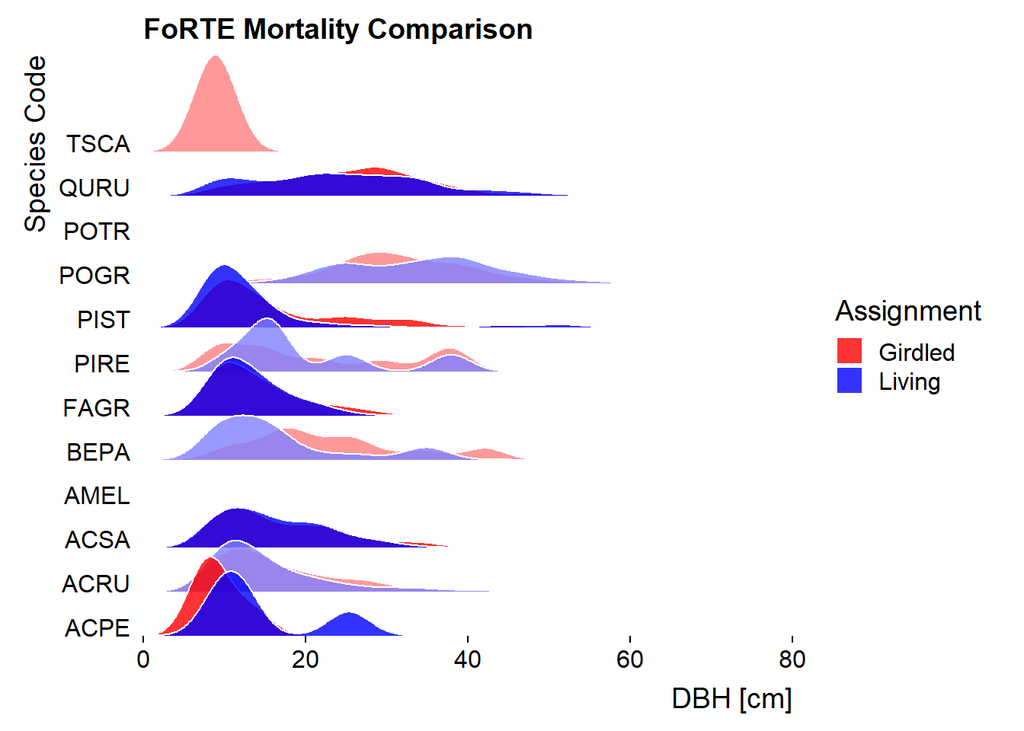

```r
## percentage of stems >40cm dbh that are aspen and birch:
pogr_ba <- inv %>%
  group_by(species) %>%
  filter(dbh_cm >= 40.0) %>%
  summarise(n = n()) # 180 total stems over 40.0 cm DBH;


# make ridge plot, girdled vs alive
mor <- fd_mortality()
x12 <- ggplot(mor, aes(y = as.factor(species)))+
geom_density_ridges(aes(x = dbh_cm, fill = paste(species, fate)),
    alpha = .8, color = "white", from = 0, to = 80) +
    labs(
        x = "DBH [cm]",
        y = "Species Code",
        title = "FoRTE Mortality Comparison") +
    scale_y_discrete(expand = c(0, 0)) +
    scale_x_continuous(expand = c(0, 0)) +
    scale_fill_cyclical(
        breaks = c("ACPE kill", "ACPE live"),
        labels = c(`ACPE kill` = "Girdled", `ACPE live` = "Living"),
        values = c("#ff0000", "#0000ff", "#ff8080", "#8080ff"),
        name = "Assignment", guide = "legend"
    ) +
    coord_cartesian(clip = "off") +
    theme_ridges(grid = FALSE)
x12
```

## Reworking some figures, adding fPAR data and whole-canopy NPP

```r
## new NPP fig with whole-canopy NPP data
## load data set

can_NPP <- read.csv("C:/github/forte_subcanopy_leaf_functional_traits/data/cleaned_data_for_analyses/three_yr_can_NPP.csv")

head(can_NPP)
```

```
##   Subplot Canopy_NPP Replicate disturbance_severity treatment Year stratum
## 1    A01E   3674.583         A                   85    bottom 2019  canopy
## 2    A01E   5648.132         A                   85    bottom 2020  canopy
## 3    A01E   2463.605         A                   85    bottom 2021  canopy
## 4    A01W   3113.404         A                   85       top 2019  canopy
## 5    A01W   4971.704         A                   85       top 2020  canopy
## 6    A01W   3290.731         A                   85       top 2021  canopy
##   log_can_NPP
## 1    8.209195
## 2    8.639080
## 3    7.809381
## 4    8.043472
## 5    8.511518
## 6    8.098865
```

```r
head(npp)
```

```
##   Year Subplot Subplot_mean_Asat disturbance_severity treatment Replicate
## 1 2019    A01E          3.199833                   85         B         A
## 2 2019    A01W          4.994333                   85         T         A
## 3 2019    A02E          4.023833                   45         T         A
## 4 2019    A02W          4.794500                   45         B         A
## 5 2019    A03E          6.260000                   65         B         A
## 6 2019    A03W          4.925333                   65         T         A
##   Subcanopy_NPP  log_NPP
## 1     217.81270 5.383636
## 2      72.11166 4.278216
## 3     286.94017 5.659274
## 4     248.10563 5.513855
## 5     172.36119 5.149592
## 6     317.75893 5.761293
```

```r
# ## now transform vector of Canopy NPP data

can_NPP$disturbance_severity <- as.factor(can_NPP$disturbance_severity)
can_NPP$treatment <- as.factor(can_NPP$treatment)
can_NPP$Year <- as.factor(can_NPP$Year)
can_NPP$Replicate <- as.factor(can_NPP$Replicate)


NPP_all <- left_join(can_NPP, npp, by = c("Subplot", "Year"))
head(NPP_all)
```

```
##   Subplot Canopy_NPP Replicate.x disturbance_severity.x treatment.x Year
## 1    A01E   3674.583           A                     85      bottom 2019
## 2    A01E   5648.132           A                     85      bottom 2020
## 3    A01E   2463.605           A                     85      bottom 2021
## 4    A01W   3113.404           A                     85         top 2019
## 5    A01W   4971.704           A                     85         top 2020
## 6    A01W   3290.731           A                     85         top 2021
##   stratum log_can_NPP Subplot_mean_Asat disturbance_severity.y treatment.y
## 1  canopy    8.209195          3.199833                     85           B
## 2  canopy    8.639080          4.828167                     85           B
## 3  canopy    7.809381          4.323333                     85           B
## 4  canopy    8.043472          4.994333                     85           T
## 5  canopy    8.511518          7.034667                     85           T
## 6  canopy    8.098865          6.835000                     85           T
##   Replicate.y Subcanopy_NPP  log_NPP
## 1           A     217.81270 5.383636
## 2           A     571.47495 6.348221
## 3           A    1509.29868 7.319400
## 4           A      72.11166 4.278216
## 5           A     515.08883 6.244339
## 6           A     701.34661 6.553002
```

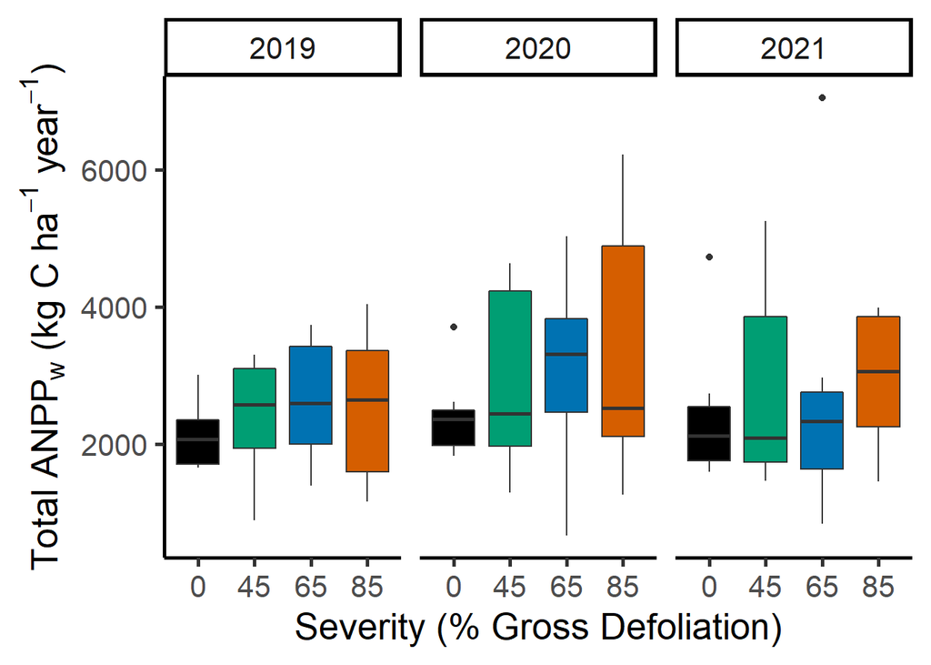

```r
NPP_all <- NPP_all %>%
  dplyr::select(Subplot, Canopy_NPP, Year, log_can_NPP, Subplot_mean_Asat, disturbance_severity.y, treatment.y, Replicate.y, Subcanopy_NPP, log_NPP) %>%
  rename(treatment = treatment.y,
         Replicate = Replicate.y,
         disturbance_severity = disturbance_severity.y,
         log_sc_NPP = log_NPP)

NPP_all <- NPP_all %>%
  rowwise() %>%
  mutate(total_NPP = sum(Subcanopy_NPP + Canopy_NPP))

bpx3 <- NPP_all %>%
  ggplot(aes(x = disturbance_severity, y = total_NPP, group_by(disturbance_severity), fill = disturbance_severity)) +
  theme_classic(base_size = 20) +
  geom_boxplot(show.legend = FALSE) +
  xlab("Severity (% Gross Defoliation)") +
  ylab(expression(paste("Total ANPP" [w], " (",kg," ",C," ",ha^-1," ",year^-1,")"))) +
  scale_fill_manual(values = c("#000000", "#009E73", "#0072B2", "#D55E00")) +
  facet_grid(~Year)

bpx3
```

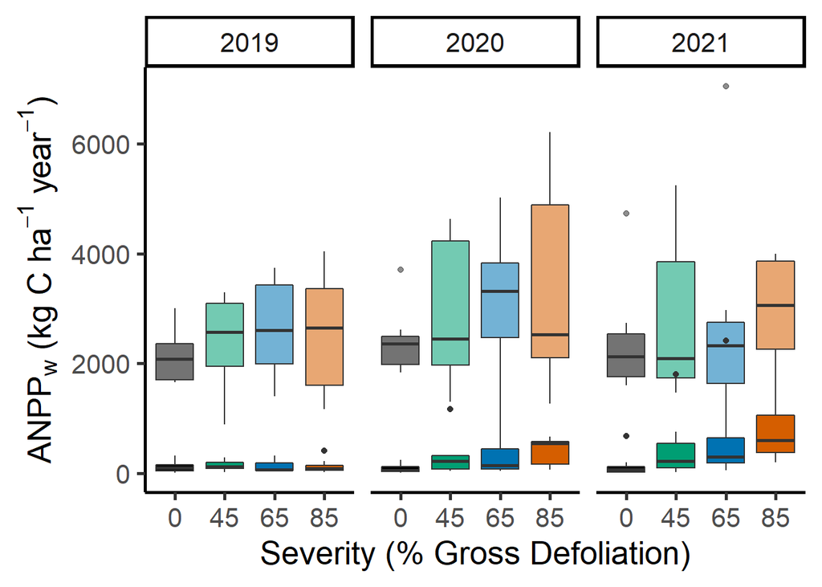

```r
bpx4 <- NPP_all %>%
  ggplot(aes(group_by(disturbance_severity))) +
  theme_classic(base_size = 20) +
  theme(legend.position = 'none') +
  geom_boxplot(aes(x = disturbance_severity, y = total_NPP, fill = disturbance_severity, show.legend=FALSE, alpha=0.15)) +
  geom_boxplot(aes(x = disturbance_severity, y = Subcanopy_NPP, fill = disturbance_severity, show.legend=FALSE)) +
  xlab("Severity (% Gross Defoliation)") + # x axis label
  ylab(expression(paste("ANPP" [w], " (",kg," ",C," ",ha^-1," ",year^-1,")"))) + # y axis label
  scale_fill_manual(values = c("#000000", "#009E73", "#0072B2", "#D55E00")) +
  facet_grid(~Year) # this lets you make separate panels for each year
bpx4
```

```r
# ## perform vector operation to calculate means and sd's
# #+++++++++++++++++++++++++
# # Function to calculate the mean and the standard deviation
#   # for each group
# #+++++++++++++++++++++++++
# # data : a data frame
# # varname : the name of a column containing the variable
#   #to be summariezed
# # groupnames : vector of column names to be used as
#   # grouping variables
#
# total_npp_means <- summarySE(NPP_all, measurevar="total_NPP", groupvars=c("disturbance_severity","Year"))
#
# # data_summary <- function(NPP_all, total_NPP, c("disturbance_severity", "Year")){
# #   require(dplyr)
# #   summary_func <- function(x, col){
# #     c(mean = mean(x[[col]], na.rm=TRUE),
# #       sd = sd(x[[col]], na.rm=TRUE))
# #   }
# #   data_sum<-ddply(data, groupnames, .fun=summary_func,
# #                   varname)
# #   data_sum <- rename(data_sum, c("mean" = varname))
# #  return(data_sum)
# # }
#
# ## try making geom_point plot for means +- sd
# gp1 <- ggplot(NPP_all, aes(x=disturbance_severity, y=len, colour=supp, group=supp)) +
#     geom_errorbar(aes(ymin=len-ci, ymax=len+ci), colour="black", width=.1, position=pd) +
#     geom_line(position=pd) +
#     geom_point(position=pd, size=3)
```

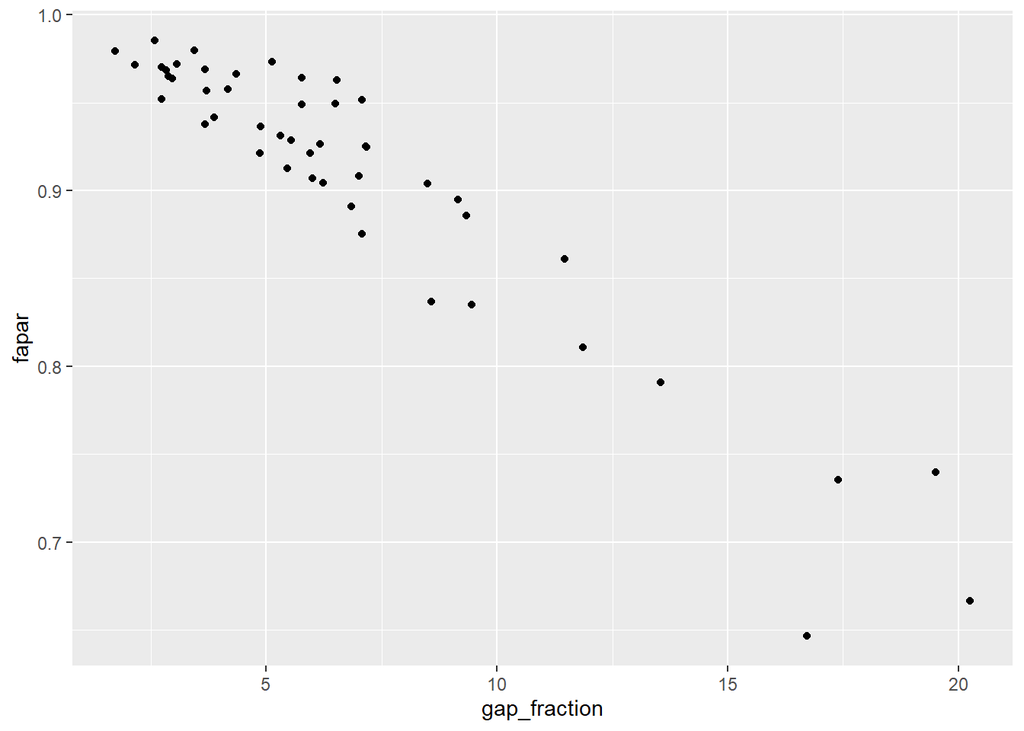

```r
## code from Jeff Atkins to estimate fPAR from camera gap fraction
require(fortedata)
require(tidyverse)
require(ggplot2)
# data
hemi <- fd_hemi_camera()
par <- fd_ceptometer()
# extract year
hemi$year <- format(as.Date(hemi$date, format="%d/%m/%Y"),"%Y")
par$year <- format(as.Date(par$timestamp, format="%d/%m/%Y"),"%Y")
# select down
x <- hemi %>%
    dplyr::select(subplot_id, year, gap_fraction, openness) %>%
    data.frame()
par %>%
    dplyr::select(subplot_id, year, fapar) %>%
    data.frame() -> y
# merge
df <- merge(x, y)
#
df %>%
    group_by(subplot_id, year) %>%
    summarize(gap_fraction = mean(gap_fraction, na.rm = TRUE),
              openness = mean(openness, na.rm = TRUE),
              fapar = mean(fapar, na.rm = TRUE)) %>%
    data.frame() -> df
# first visual
x11()
ggplot(df, aes(x = gap_fraction, y = fapar))+
    geom_point()
```

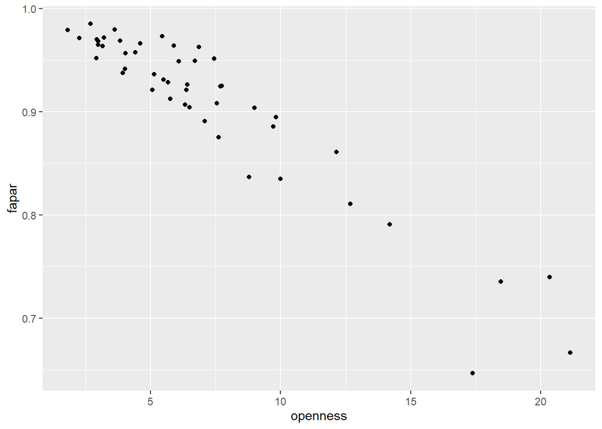

```r
x11()
ggplot(df, aes(x = openness, y = fapar))+
    geom_point()
```

```r
# model
summary(lm(fapar ~ gap_fraction, data = df))
```

```
##
## Call:
## lm(formula = fapar ~ gap_fraction, data = df)
##
## Residuals:
##       Min        1Q    Median        3Q       Max
## -0.094349 -0.016253 -0.002973  0.020001  0.049094
##
## Coefficients:
##                Estimate Std. Error t value Pr(>|t|)
## (Intercept)   1.0248811  0.0071085  144.18   <2e-16 ***
## gap_fraction -0.0169964  0.0008757  -19.41   <2e-16 ***
## ---
## Signif. codes:  0 '***' 0.001 '**' 0.01 '*' 0.05 '.' 0.1 ' ' 1
##
## Residual standard error: 0.02644 on 46 degrees of freedom
## Multiple R-squared:  0.8912, Adjusted R-squared:  0.8888
## F-statistic: 376.7 on 1 and 46 DF,  p-value: < 2.2e-16
```

```r
summary(lm(fapar ~ openness, data = df))
```

```
##
## Call:
## lm(formula = fapar ~ openness, data = df)
##
## Residuals:
##       Min        1Q    Median        3Q       Max
## -0.097235 -0.016404 -0.003671  0.018745  0.048918
##
## Coefficients:
##               Estimate Std. Error t value Pr(>|t|)
## (Intercept)  1.0252446  0.0072259  141.88   <2e-16 ***
## openness    -0.0161978  0.0008469  -19.13   <2e-16 ***
## ---
## Signif. codes:  0 '***' 0.001 '**' 0.01 '*' 0.05 '.' 0.1 ' ' 1
##
## Residual standard error: 0.02678 on 46 degrees of freedom
## Multiple R-squared:  0.8883, Adjusted R-squared:  0.8859
## F-statistic: 365.8 on 1 and 46 DF,  p-value: < 2.2e-16
```

```r
# calculate MSE from gap fraction model for use in fPAR function in next section
summ2 <- summary(lm(fapar ~ gap_fraction, data = df))
mean(summ2$residuals)
```

```
## [1] -1.454303e-18
```